# BFL on PHMRC: reproducing the AP results across three label-shift cases

Yu Zhu, Jason Teng, Zehang Richard Li

This example runs the paper’s BFL variants on the real **PHMRC** verbal-autopsy data, with **AP** (Andhra Pradesh) as the target and the other five sites as sources, across the three within-target label-shift settings from the paper:

- **Case I — no shift** (20% of AP labeled): baselines + **base**, **domain**, **partial**, **mix**.
- **Case II — mild shift**: baselines + **domain**, **partial**, **mix**.
- **Case III — severe shift**: baselines + **domain**, **partial**, **mix**.

`base` uses no target labels, so it is shift-invariant and only run in Case I. The point is to show how each variant is a single **`run_BFL()`** call followed by **`score_BFL()`** — the only things that change are the arguments you pass. Notice that the shift cases flip **`label_shift = TRUE`** and score on the unlabeled subset via **`eval_idx`**; everything else is the same call. The LCVA fitting and summary assembly live in `helpers.R`. Requires `LCVA` and `BFL`; the PHMRC data is bundled, so run from this folder.

```r
source("helpers.R")   # LCVA + PHMRC glue + per-variant input builders + baselines
```

The two **baselines** (`local_self`, `local_avg`) are LCVA models that do *not* use the BFL package; they are shown for comparison, as in the paper. Each `inputs_*(ctx)` assembles that variant’s `local_summaries` (and `X_target`, `Y_target`, `Y_add`) from the LCVA phis; the package calls are written out below.

# Case I: no within-target label shift

Load AP and the five sources, fit each source’s local LCVA model, and split AP into 20% labeled / 80% unlabeled. (The LCVA fits are the slow part.)

```r
ctx1 <- prepare_ap(target  = "AP",
                   sources = c("Mexico", "Bohol", "Dar", "Pemba", "UP"),
                   seed = 1, shift = "no_shift")
```

[output not shown]

```r
c(N = length(ctx1$Y_new), labeled = length(ctx1$labeled),
  unlabeled = length(ctx1$missing), sources = length(ctx1$src_sites))
```

```
#>         N   labeled unlabeled   sources
#>      1554       311      1243         5
```

## Baselines: local-self and local-avg

```r
b1_self <- local_self(ctx1)
```

```
#> Stacking 3 chains, with 311 data points and 1500 posterior draws;
#>  using stan optimizer, max iterations = 1e+05
#>
#>  Total elapsed time for approximate LOO and stacking = 18.6 s
#> [1] "Number of posterior draws from each chain:"
#> w[1] w[2] w[3]
#>  287 1321  392
```

```r
b1_avg  <- local_avg(ctx1)
```

[output not shown]

```r
round(rbind(local_self = b1_self, local_avg = b1_avg), 4)
```

```
#>              top1 top1bal   csmf
#> local_self 0.2936  0.1818 0.6105
#> local_avg  0.2351  0.1822 0.6285
```

## base — sources only, no target labels

```r
inp <- inputs_base(ctx1)
fit_base <- run_BFL(inp$local_summaries, X_target = inp$X_target,
                    Y_target = inp$Y_target, label_shift = ctx1$label_shift,
                    sampler = "gibbs")
sc_base  <- score_BFL(fit_base, Y_eval = inp$Y_eval, eval_idx = inp$eval_idx)
c(top1 = sc_base$top1_acc, top1bal = sc_base$balanced_acc, csmf = sc_base$csmf_acc)
```

```
#>      top1   top1bal      csmf
#> 0.2940798 0.2363677 0.5563760
```

## domain — sources + target self-model

The labeled rows train a self-model (added to `local_summaries`); their truth is passed as `Y_add` for the CSMF correction. `Y_target = NULL`.

```r
inp <- inputs_domain(ctx1)
```

```
#> Stacking 3 chains, with 311 data points and 1500 posterior draws;
#>  using stan optimizer, max iterations = 1e+05
#>
#>  Total elapsed time for approximate LOO and stacking = 20.25 s
#> [1] "Number of posterior draws from each chain:"
#> w[1] w[2] w[3]
#>  287 1321  392
```

```r
fit_dom <- run_BFL(inp$local_summaries, X_target = inp$X_target,
                   Y_target = inp$Y_target, Y_add = inp$Y_add,
                   label_shift = ctx1$label_shift, sampler = "gibbs")
sc_dom  <- score_BFL(fit_dom, Y_eval = inp$Y_eval, eval_idx = inp$eval_idx)
c(top1 = sc_dom$top1_acc, top1bal = sc_dom$balanced_acc, csmf = sc_dom$csmf_acc)
```

```
#>      top1   top1bal      csmf
#> 0.3226066 0.2541346 0.7172464
```

## partial — labels fed into the model

The observed labels go straight into `Y_target` (`NA` on the unlabeled rows).

```r
inp <- inputs_partial(ctx1)
fit_par <- run_BFL(inp$local_summaries, X_target = inp$X_target,
                   Y_target = inp$Y_target, label_shift = ctx1$label_shift,
                   sampler = "gibbs")
sc_par  <- score_BFL(fit_par, Y_eval = inp$Y_eval, eval_idx = inp$eval_idx)
c(top1 = sc_par$top1_acc, top1bal = sc_par$balanced_acc, csmf = sc_par$csmf_acc)
```

```
#>      top1   top1bal      csmf
#> 0.3097345 0.2607113 0.6912915
```

## mix — a split of both

Half the labeled rows (per cause) train the self-model; the other half enter as partial labels. Both `Y_target` and `Y_add` are supplied.

```r
inp <- inputs_mix(ctx1)
```

```
#> Stacking 3 chains, with 152 data points and 1500 posterior draws;
#>  using stan optimizer, max iterations = 1e+05
#>
#>  Total elapsed time for approximate LOO and stacking = 17.62 s
#> [1] "Number of posterior draws from each chain:"
#> w[1] w[2] w[3]
#>  403  223 1374
```

```r
fit_mix <- run_BFL(inp$local_summaries, X_target = inp$X_target,
                   Y_target = inp$Y_target, Y_add = inp$Y_add,
                   label_shift = ctx1$label_shift, sampler = "gibbs")
sc_mix  <- score_BFL(fit_mix, Y_eval = inp$Y_eval, eval_idx = inp$eval_idx)
c(top1 = sc_mix$top1_acc, top1bal = sc_mix$balanced_acc, csmf = sc_mix$csmf_acc)
```

```
#>      top1   top1bal      csmf
#> 0.3024940 0.2559061 0.6792364
```

## Accuracy across methods (Case I)

```r
round(rbind(
  local_self = b1_self,
  local_avg  = b1_avg,
  base    = c(top1 = sc_base$top1_acc, top1bal = sc_base$balanced_acc, csmf = sc_base$csmf_acc),
  domain  = c(top1 = sc_dom$top1_acc,  top1bal = sc_dom$balanced_acc,  csmf = sc_dom$csmf_acc),
  partial = c(top1 = sc_par$top1_acc,  top1bal = sc_par$balanced_acc,  csmf = sc_par$csmf_acc),
  mix     = c(top1 = sc_mix$top1_acc,  top1bal = sc_mix$balanced_acc,  csmf = sc_mix$csmf_acc)
), 4)
```

```
#>              top1 top1bal   csmf
#> local_self 0.2936  0.1818 0.6105
#> local_avg  0.2351  0.1822 0.6285
#> base       0.2941  0.2364 0.5564
#> domain     0.3226  0.2541 0.7172
#> partial    0.3097  0.2607 0.6913
#> mix        0.3025  0.2559 0.6792
```

## Inspecting a fit: the S3 methods

Every `run_BFL()` fit has class `BFL` and every `score_BFL()` result has class `BFL_score`, each with `print` / `summary` / `plot`. Shown here for `domain`.

```r
fit_dom
```

```
#> BFL Fit
#> ────────────────────────────────────────
#>   Records   : 1243
#>   Causes    : 34
#>   Models    : 6 (Mexico, Bohol, Dar, Pemba, UP, AP)
#>   Post draws: 4000
#>   Variant   : no partial labels, CSMF correction
#> ────────────────────────────────────────
#>   Top causes: 3 (18.8%), 19 (11.1%), 15 (9.3%)
#>   Run summary() for full CSMF table.
```

```r
summary(fit_dom)
```

```
#> BFL Results
#> ────────────────────────────────────────────────────────────
#>   Records: 1243  |  Models: 6  |  Causes: 34  |  Draws: 4000
#> ────────────────────────────────────────────────────────────
#>
#> Cause-Specific Mortality Fractions (95% CI):
#>   Cause                    Mean   Lower   Upper
#>   -------------------------------------------------------
#>   3                       18.8%   15.6%   22.1%  ██░░░░░░░░░░
#>   19                      11.1%    8.8%   13.6%  █░░░░░░░░░░░
#>   15                       9.3%    7.5%   11.3%  █░░░░░░░░░░░
#>   5                        8.8%    6.9%   10.8%  █░░░░░░░░░░░
#>   8                        7.3%    5.5%    9.2%  █░░░░░░░░░░░
#>   26                       6.8%    5.0%    8.7%  █░░░░░░░░░░░
#>   10                       6.6%    5.2%    8.2%  █░░░░░░░░░░░
```

[output cut: 67 more lines]

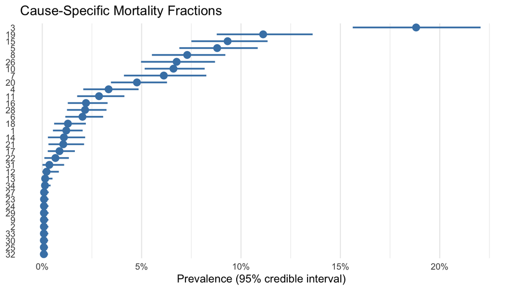

```r
plot(fit_dom)
```

```r
sc_dom
```

```
#> BFL Score
#> ────────────────────────────────────────
#>   Top-1 accuracy  : 32.3%
#>   Balanced acc.   : 25.4%
#>   CSMF accuracy   : 71.7%
#> ────────────────────────────────────────
#>   Run summary() for per-cause detail, plot() for visuals.
```

```r
summary(sc_dom)
```

```
#> BFL Score
#> ─────────────────────────────────────────────────────────────────
#>   Top-1 accuracy  : 32.3%   Balanced: 25.4%   CSMF: 71.7%
#> ─────────────────────────────────────────────────────────────────
#>
#> Per-Cause Detail:
#>   Cause                  TruePrev EstPrev  CSMFerr  Recall
#>   --------------------------------------------------------------
#>   8                         8.8%    7.2%    -1.6%   40.9%  ████░░░░░░
#>   15                        8.0%    9.2%    +1.2%   66.3%  ███████░░░
#>   7                         6.6%    6.2%    -0.3%   11.1%  █░░░░░░░░░
#>   5                         6.5%    8.5%    +2.0%   61.5%  ██████░░░░
#>   20                        6.5%    4.8%    -1.7%   38.8%  ████░░░░░░
#>   13                        5.8%    1.1%    -4.7%    0.0%  ░░░░░░░░░░
#>   18                        5.7%    2.3%    -3.4%   10.1%  █░░░░░░░░░
```

[output cut: 27 more lines]

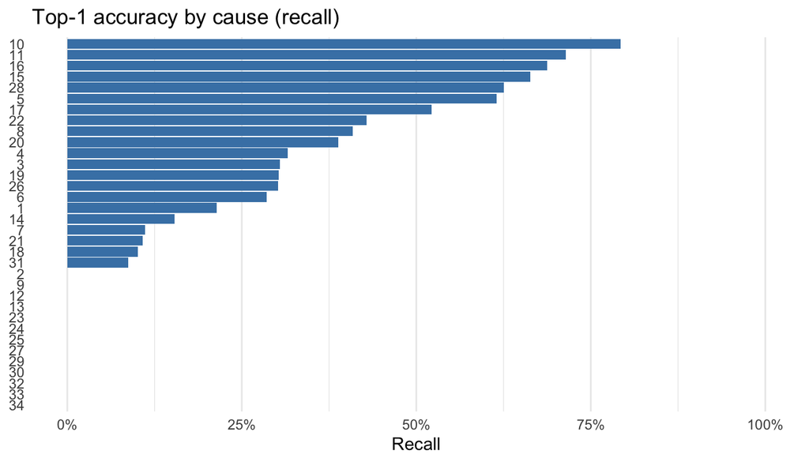

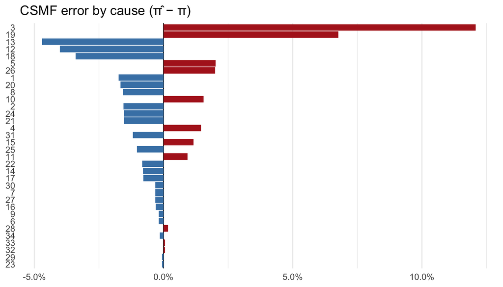

```r
plot(sc_dom)
```

# Case II: mild within-target label shift

`prepare_ap(shift = "mild")` builds a labeled/unlabeled split with a *mild* prevalence shift between the two halves (a stacked frame drawn from independent Dirichlet prevalences). The BFL calls are identical to Case I except `label_shift = TRUE`, and scoring is on the unlabeled subset (`eval_idx`); `base` is omitted (it is shift-invariant).

```r
ctx2 <- prepare_ap(target  = "AP",
                   sources = c("Mexico", "Bohol", "Dar", "Pemba", "UP"),
                   seed = 1, shift = "mild")
```

[output not shown]

## Baselines

```r
b2_self <- local_self(ctx2)
```

```
#> Stacking 3 chains, with 343 data points and 1500 posterior draws;
#>  using stan optimizer, max iterations = 1e+05
#>
#>  Total elapsed time for approximate LOO and stacking = 21.31 s
#> [1] "Number of posterior draws from each chain:"
#> w[1] w[2] w[3]
#>  309  597 1094
```

```r
b2_avg  <- local_avg(ctx2)
```

[output not shown]

```r
round(rbind(local_self = b2_self, local_avg = b2_avg), 4)
```

```
#>              top1 top1bal   csmf
#> local_self 0.2357  0.2863 0.3791
#> local_avg  0.1765  0.1967 0.4532
```

## BFL fits (domain, partial, mix)

```r
inp    <- inputs_domain(ctx2)
```

```
#> Stacking 3 chains, with 343 data points and 1500 posterior draws;
#>  using stan optimizer, max iterations = 1e+05
#>
#>  Total elapsed time for approximate LOO and stacking = 18.07 s
#> [1] "Number of posterior draws from each chain:"
#> w[1] w[2] w[3]
#>  309  597 1094
```

```r
sc_dom2 <- score_BFL(run_BFL(inp$local_summaries, X_target = inp$X_target,
                             Y_target = inp$Y_target, Y_add = inp$Y_add,
                             label_shift = ctx2$label_shift, sampler = "gibbs"),
                     Y_eval = inp$Y_eval, eval_idx = inp$eval_idx)

inp    <- inputs_partial(ctx2)
sc_par2 <- score_BFL(run_BFL(inp$local_summaries, X_target = inp$X_target,
                             Y_target = inp$Y_target,
                             label_shift = ctx2$label_shift, sampler = "gibbs"),
                     Y_eval = inp$Y_eval, eval_idx = inp$eval_idx)

inp    <- inputs_mix(ctx2)
```

```
#> Stacking 3 chains, with 161 data points and 1500 posterior draws;
#>  using stan optimizer, max iterations = 1e+05
#>
#>  Total elapsed time for approximate LOO and stacking = 17.68 s
#> [1] "Number of posterior draws from each chain:"
#> w[1] w[2] w[3]
#>  539  294 1167
```

```r
sc_mix2 <- score_BFL(run_BFL(inp$local_summaries, X_target = inp$X_target,
                             Y_target = inp$Y_target, Y_add = inp$Y_add,
                             label_shift = ctx2$label_shift, sampler = "gibbs"),
                     Y_eval = inp$Y_eval, eval_idx = inp$eval_idx)
```

## Accuracy across methods (Case II)

```r
round(rbind(
  local_self = b2_self,
  local_avg  = b2_avg,
  domain  = c(top1 = sc_dom2$top1_acc, top1bal = sc_dom2$balanced_acc, csmf = sc_dom2$csmf_acc),
  partial = c(top1 = sc_par2$top1_acc, top1bal = sc_par2$balanced_acc, csmf = sc_par2$csmf_acc),
  mix     = c(top1 = sc_mix2$top1_acc, top1bal = sc_mix2$balanced_acc, csmf = sc_mix2$csmf_acc)
), 4)
```

```
#>              top1 top1bal   csmf
#> local_self 0.2357  0.2863 0.3791
#> local_avg  0.1765  0.1967 0.4532
#> domain     0.3403  0.3729 0.4876
#> partial    0.2293  0.2683 0.3828
#> mix        0.2711  0.2964 0.4070
```

# Case III: severe within-target label shift

`prepare_ap(shift = "severe")` draws a *severe* shift (per-cause Beta(0.2, 0.2) unlabeled fractions, so some causes are almost entirely unlabeled). The calls are again identical except the split, and `domain`/`mix` place the target self-model by its self-generated (new-space) causes — both handled inside the input builders, so the `run_BFL()`/`score_BFL()` calls do not change.

```r
ctx3 <- prepare_ap(target  = "AP",
                   sources = c("Mexico", "Bohol", "Dar", "Pemba", "UP"),
                   seed = 1, shift = "severe")
```

[output not shown]

## Baselines

```r
b3_self <- local_self(ctx3)
```

```
#> Stacking 3 chains, with 704 data points and 1500 posterior draws;
#>  using stan optimizer, max iterations = 1e+05
#>
#>  Total elapsed time for approximate LOO and stacking = 18.67 s
#> [1] "Number of posterior draws from each chain:"
#> w[1] w[2] w[3]
#>  743  873  384
```

```r
b3_avg  <- local_avg(ctx3)
```

[output not shown]

```r
round(rbind(local_self = b3_self, local_avg = b3_avg), 4)
```

```
#>              top1 top1bal   csmf
#> local_self 0.0400  0.1315 0.0880
#> local_avg  0.1633  0.1815 0.3165
```

## BFL fits (domain, partial, mix)

```r
inp    <- inputs_domain(ctx3)
```

```
#> Stacking 3 chains, with 704 data points and 1500 posterior draws;
#>  using stan optimizer, max iterations = 1e+05
#>
#>  Total elapsed time for approximate LOO and stacking = 17.81 s
#> [1] "Number of posterior draws from each chain:"
#> w[1] w[2] w[3]
#>  743  873  384
```

```r
sc_dom3 <- score_BFL(run_BFL(inp$local_summaries, X_target = inp$X_target,
                             Y_target = inp$Y_target, Y_add = inp$Y_add,
                             label_shift = ctx3$label_shift, sampler = "gibbs"),
                     Y_eval = inp$Y_eval, eval_idx = inp$eval_idx)

inp    <- inputs_partial(ctx3)
sc_par3 <- score_BFL(run_BFL(inp$local_summaries, X_target = inp$X_target,
                             Y_target = inp$Y_target,
                             label_shift = ctx3$label_shift, sampler = "gibbs"),
                     Y_eval = inp$Y_eval, eval_idx = inp$eval_idx)

inp    <- inputs_mix(ctx3)
```

```
#> Stacking 3 chains, with 346 data points and 1500 posterior draws;
#>  using stan optimizer, max iterations = 1e+05
#>
#>  Total elapsed time for approximate LOO and stacking = 18.27 s
#> [1] "Number of posterior draws from each chain:"
#> w[1] w[2] w[3]
#>    0  759 1241
```

```r
sc_mix3 <- score_BFL(run_BFL(inp$local_summaries, X_target = inp$X_target,
                             Y_target = inp$Y_target, Y_add = inp$Y_add,
                             label_shift = ctx3$label_shift, sampler = "gibbs"),
                     Y_eval = inp$Y_eval, eval_idx = inp$eval_idx)
```

## Accuracy across methods (Case III)

```r
round(rbind(
  local_self = b3_self,
  local_avg  = b3_avg,
  domain  = c(top1 = sc_dom3$top1_acc, top1bal = sc_dom3$balanced_acc, csmf = sc_dom3$csmf_acc),
  partial = c(top1 = sc_par3$top1_acc, top1bal = sc_par3$balanced_acc, csmf = sc_par3$csmf_acc),
  mix     = c(top1 = sc_mix3$top1_acc, top1bal = sc_mix3$balanced_acc, csmf = sc_mix3$csmf_acc)
), 4)
```

```
#>              top1 top1bal   csmf
#> local_self 0.0400  0.1315 0.0880
#> local_avg  0.1633  0.1815 0.3165
#> domain     0.1341  0.1348 0.3571
#> partial    0.2329  0.2311 0.4479
#> mix        0.1765  0.1565 0.3785
```